# Testing Code

Sergio Mora

The purpose of this RMD is to test out code prior to placing it in the shiny ui or server. This will facilitate the debugging process. This code is meant to be read as scrap paper and not as a version one of the shiny app. For that reason this code RMD file does not have to follow the Shiny app layout or structure. It also might not work entirely.

# Reading in the data

```r
#Utilizing the Chess.com API to pull in the top fifty players for each type of chess rules. We will begin with "Daily" (easiet to understand and most data on it) and we will usitlize that as the parameter. This first API will be utilized to pull more API's. It'll be a master table of sorts.
referrence_table <- fromJSON(
    "https://api.chess.com/pub/leaderboards"
    )

top50 <- referrence_table$daily

stats_apis_list <- as.list((paste0(top50$'@id',"/stats")))

list_of_stats <- lapply(stats_apis_list,fromJSON)
```

```r
col.names <- colnames(data.frame(list_of_stats[[1]]$chess_daily)) # list of the column names since the empty dataframe wont have this by default

col.num <- ncol(data.frame(list_of_stats[[1]]$chess_daily)) # number of columns needed for our empty data frame

row.num <- nrow(top50) # number of rows, this might be repetative since we know it should always be 50 but just in case something goes wrong

all_stats <- data.frame(matrix(ncol = col.num, nrow = row.num)) # list of column list

all_fide <- data.frame(matrix(ncol = 1, nrow = row.num)) # list of column list

for (i in 1:row.num){
#all_stats[i,] <- merge(data.frame(list_of_stats[[i]]$chess_daily),data.frame(list_of_stats[[i]]$fide))
all_stats[i,] <- data.frame(list_of_stats[[i]]$chess_daily)
#all_fide[i,] <- data.frame(list_of_stats[[i]]$fide,is.na = TRUE)
#all_stats[i,] <- data.frame(list_of_stats[[i]]$fide)
}


colnames(all_stats) <- col.names

all_stats <- cbind(top50[c("player_id","username","rank","country","title","status")],all_stats) # Binding the data based on the position.

country_codes <- read.csv("https://gist.githubusercontent.com/tadast/8827699/raw/f5cac3d42d16b78348610fc4ec301e9234f82821/countries_codes_and_coordinates.csv")

country_codes <- country_codes %>% distinct(Alpha.2.code, .keep_all = TRUE) %>% mutate(country_code = gsub(" ","",Alpha.2.code)) %>% dplyr::select(country_code,Country,Latitude..average.,Longitude..average.)

new_countries <- data.frame(c("XE","XS"),c("Europe","Serbia"),c(54.5260,44.0000),c(15.2551,21.0000))
names(new_countries) <- names(country_codes)

country_codes <- rbind(country_codes,new_countries)


all_stats$country <- substr(all_stats$country,nchar(all_stats$country)-1,nchar(all_stats$country))



all_stats <- left_join(all_stats,country_codes,by = c("country" = "country_code")) %>% mutate(minutes_between_moves = round((record.time_per_move/60),2))
head(all_stats)
```

```
##   player_id            username rank country title  status last.rating
## 1   7848044       francisbegbie    1      XE    FM premium        2611
## 2   4147249              mizant    2      RS    FM premium        2566
## 3   1629533              Mackus    3      US    NM premium        2559
## 4 152749737   Robinko_Gindomill    4      BR  <NA>   basic        2548
## 5   4767295               XQUSE    5      US  <NA> premium        2543
## 6  64443566 IMUffeVinther-Schou    6      DK    IM premium        2535
##    last.date last.rd best.rating  best.date
## 1 1638179517     181        2611 1622521963
## 2 1636804202     284        2566 1635844881
## 3 1637766377     131        2672 1275277208
## 4 1638186089     101        2548 1637733310
## 5 1637967544     176        2543 1596591515
## 6 1635868871      79        2550 1630516205
##                                    best.game record.win record.loss record.draw
```

[output cut: 20 more lines]

Now that we have our data we can now start creating graphs and charts to explain our analysis.

# Data Exploration

Now that we have our data pulled and organized we want to start building some EDA’s.

## World Map EDA

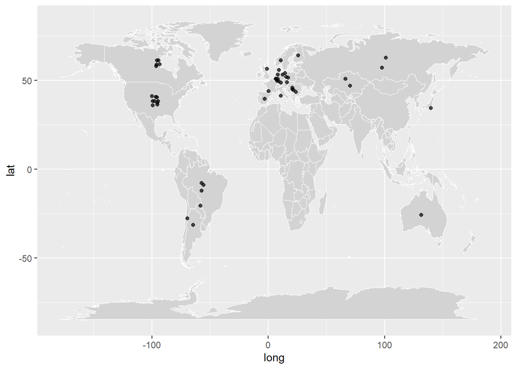

```r
set.seed(123)
all_stats <-all_stats %>% mutate(Latitude..average.jit = jitter(all_stats$Latitude..average., amount = 3),Longitude..average.jit = jitter(all_stats$Longitude..average., amount = 3))

world <- map_data("world")
ggplot() +
  geom_map(
    data = world, map = world,
    aes(long, lat, map_id = region),
    color = "white", fill = "lightgray", size = 0.1
  ) +  geom_point(
    data = all_stats,
    aes(Longitude..average.jit, Latitude..average.jit),
    alpha = 0.7,) +
  geom_point(position=position_jitter(width=.1, height=.1))
```

```r
country_lists <- data.frame(table(all_stats$Country))
colnames(country_lists) <- c("Country/Region","# of ranked players")
country_lists %>% kable()
```

| Country/Region | # of ranked players |
| --- | --- |
| Argentina | 1 |
| Australia | 1 |
| Austria | 1 |
| Brazil | 3 |
| Bulgaria | 1 |
| Canada | 5 |
| Chile | 1 |
| Czech Republic | 2 |
| Denmark | 2 |
| Europe | 2 |
| Finland | 1 |
| France | 1 |
| Germany | 4 |
| Italy | 1 |
| Japan | 1 |
| Kazakhstan | 2 |
| Netherlands | 2 |
| Norway | 1 |
| Paraguay | 1 |
| Russian Federation | 2 |
| Serbia | 3 |
| Spain | 1 |
| United Kingdom | 1 |
| United States | 9 |

From the first EDA we see where most of our ranked player are from. Very often we see that players are from first world countries in the West. This isn’t **always** the case but it is often enough.

## Bar Plot

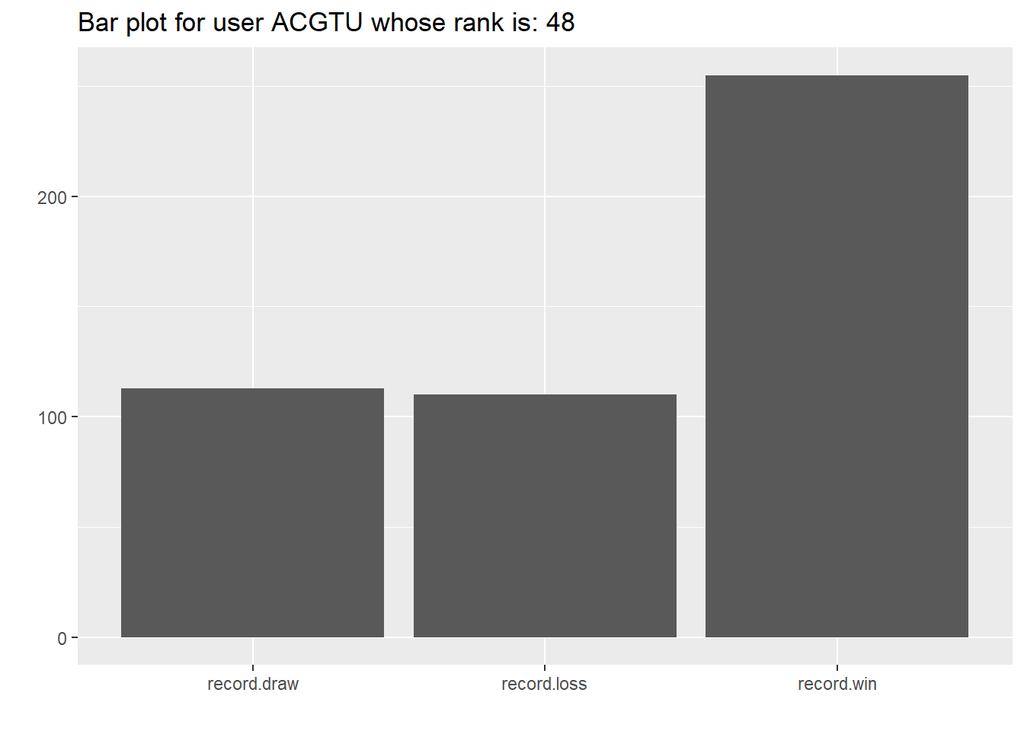

```r
#WLD data along with rank
all_stats_summary_WLD <- all_stats %>% dplyr::select(username,record.win,record.loss,record.draw,rank)

all_stats_summary_WLD <- gather(all_stats_summary_WLD,key = "record", value = "WLD",record.win,record.loss,record.draw) %>% arrange(username)

user <- "ACGTU"

all_stats_summary_WLD_user <- all_stats_summary_WLD %>% filter(username == user)

ggplot(all_stats_summary_WLD_user,aes(x = record,y=WLD)) + geom_bar(stat="identity") + ggtitle(paste0("Bar plot for user ",all_stats_summary_WLD_user$username," whose rank is: ",all_stats_summary_WLD_user$rank)) + xlab("") + ylab("")
```

```r
all_stats_summary_WLD_user
```

```
##   username rank      record WLD
## 1    ACGTU   48  record.win 255
## 2    ACGTU   48 record.loss 110
## 3    ACGTU   48 record.draw 113
```

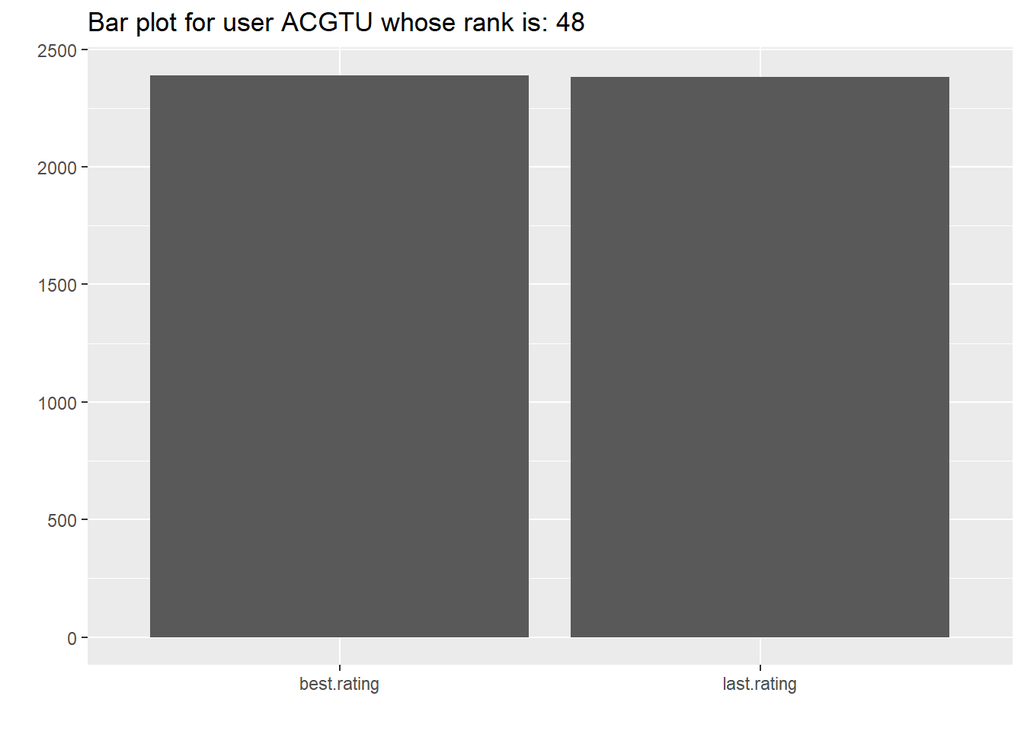

```r
#Last rating VS. Best Rating
all_stats_summary_rating <- all_stats %>% dplyr::select(username,last.rating,best.rating,rank)

all_stats_summary_rating <- gather(all_stats_summary_rating,key = "record", value = "Rating",last.rating,best.rating) %>% arrange(username)

all_stats_summary_rating_user <- all_stats_summary_rating %>% filter(username == user)

ggplot(all_stats_summary_rating_user,aes(x = record,y=Rating)) + geom_bar(stat="identity") + ggtitle(paste0("Bar plot for user ",all_stats_summary_rating_user$username," whose rank is: ",all_stats_summary_rating_user$rank)) + xlab("") + ylab("")
```

This bar plot will be utilized to measure the draw, loss, win records for each player. We will also measure the players last rating vs. their best rating. It’s often that their best rating and their last rating is one and the same due to a sampling bias. Players who rank at the top 50 normally do so when they are at their peak.

## Histogram

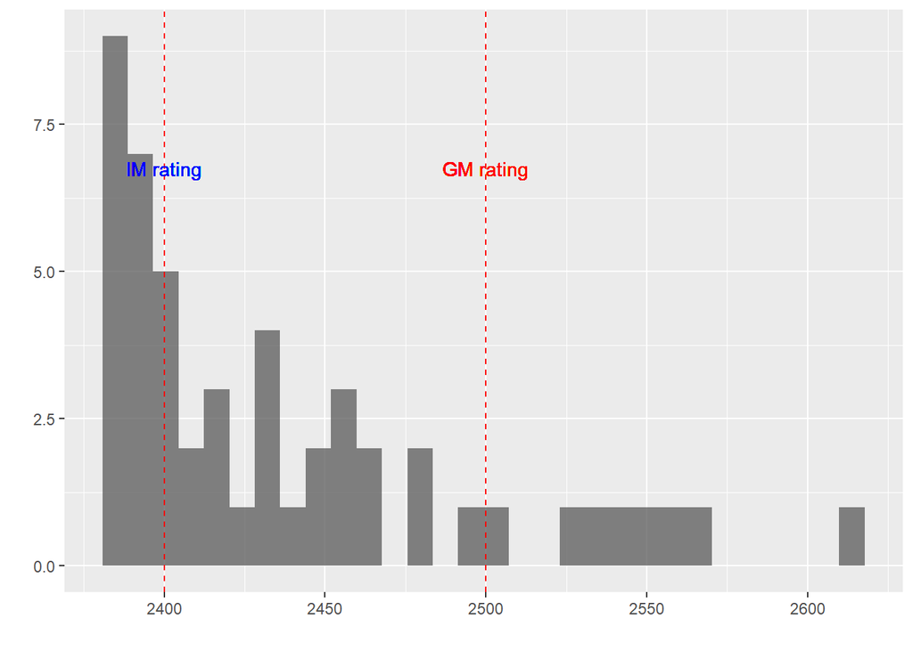

```r
# Histogram of the last rating
ggplot(all_stats, aes(x=last.rating)) +
  geom_histogram(alpha = 0.75) + geom_vline(xintercept = 2500, linetype = "dashed", color = "red") +
  geom_text(aes(x=2500, label="\nGM rating", y=7), colour="Red", text=element_text(size=11)) +
  geom_vline(xintercept = 2400, linetype = "dashed", color = "red") +
  geom_text(aes(x=2400, label="\nIM rating", y=7), colour="blue", text=element_text(size=11)) +
  ylab("") +
  xlab("")
```

```r
all_stats %>% select(player_id,last.rating,rank)
```

```
##    player_id last.rating rank
## 1    7848044        2611    1
## 2    4147249        2566    2
## 3    1629533        2559    3
## 4  152749737        2548    4
## 5    4767295        2543    5
## 6   64443566        2535    6
## 7   27902236        2528    7
## 8    2810922        2504    8
## 9    1946148        2499    9
## 10   2883344        2479   10
## 11   9898424        2478   11
## 12  21510544        2465   12
## 13   2482149        2460   13
## 14  45500830        2458   14
```

[output cut: 36 more lines]

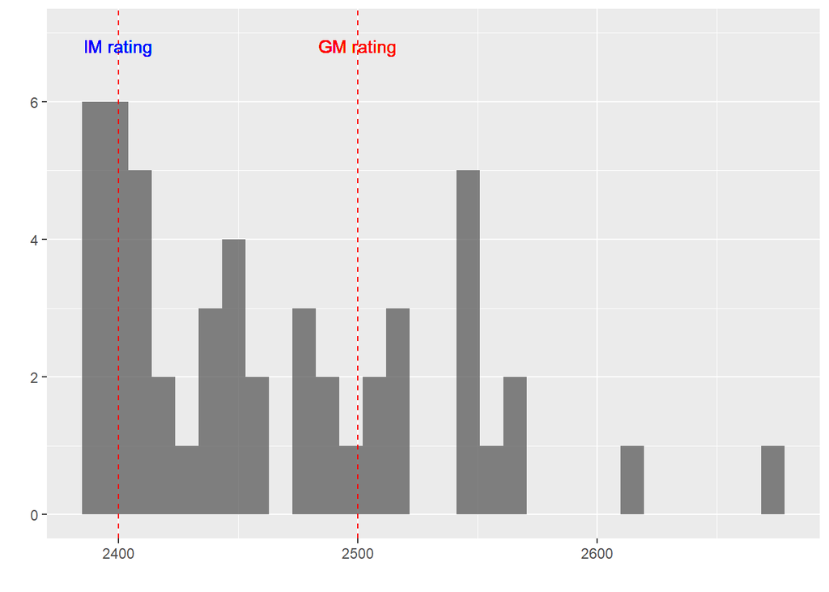

```r
# Histogram of the best rating
ggplot(all_stats, aes(x=best.rating)) +
  geom_histogram(alpha = 0.75) + geom_vline(xintercept = 2500, linetype = "dashed", color = "red") +
  geom_text(aes(x=2500, label="\nGM rating", y=7), colour="Red", text=element_text(size=11)) +
  geom_vline(xintercept = 2400, linetype = "dashed", color = "red") +
  geom_text(aes(x=2400, label="\nIM rating", y=7), colour="blue", text=element_text(size=11)) +
  ylab("") +
  xlab("")
```

```r
all_stats %>% select(player_id,best.rating,rank)
```

```
##    player_id best.rating rank
## 1    7848044        2611    1
## 2    4147249        2566    2
## 3    1629533        2672    3
## 4  152749737        2548    4
## 5    4767295        2543    5
## 6   64443566        2550    6
## 7   27902236        2560    7
## 8    2810922        2517    8
## 9    1946148        2499    9
## 10   2883344        2479   10
## 11   9898424        2485   11
## 12  21510544        2516   12
## 13   2482149        2460   13
## 14  45500830        2509   14
```

[output cut: 36 more lines]

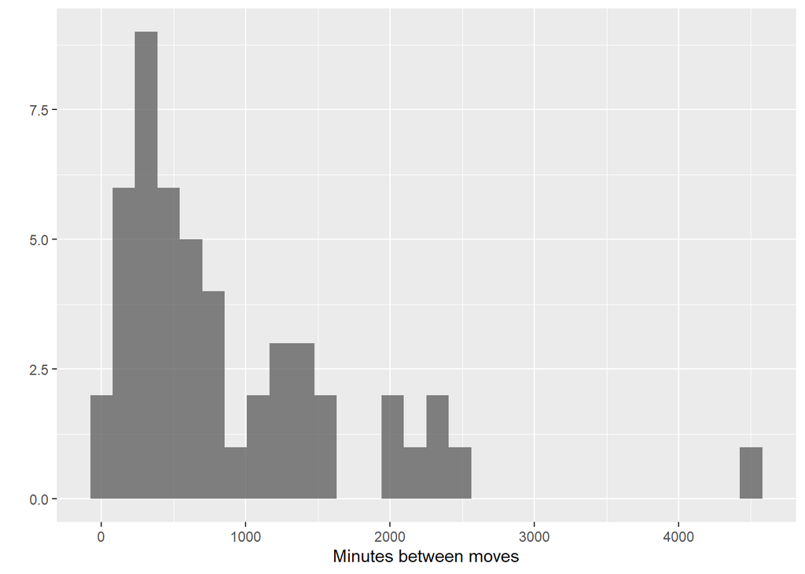

```r
# Average time spent between moves
ggplot(all_stats, aes(x=minutes_between_moves)) +
  geom_histogram(alpha = 0.75) +
  ylab("") +
  xlab("Minutes between moves")
```

```r
all_stats %>% select(player_id,minutes_between_moves,rank)
```

```
##    player_id minutes_between_moves rank
## 1    7848044                250.13    1
## 2    4147249                375.52    2
## 3    1629533                193.70    3
## 4  152749737                 58.42    4
## 5    4767295                573.33    5
## 6   64443566                294.78    6
## 7   27902236               1550.52    7
## 8    2810922                363.00    8
## 9    1946148                399.15    9
## 10   2883344               1194.17   10
## 11   9898424                287.37   11
## 12  21510544               2281.23   12
## 13   2482149                476.87   13
## 14  45500830                423.75   14
```

[output cut: 36 more lines]

Creating the Statiscal Summary Table

```r
summary_tables <- rbind(
all_stats %>% mutate(Means = mean(best.rating),Medians = median(best.rating),SDs = sd(best.rating)) %>% select(starts_with(c("Means","Medians","SDs"))) %>% distinct(),

all_stats %>% mutate(Means = mean(last.rating),Medians = median(last.rating),SDs = sd(last.rating)) %>% select(starts_with(c("Means","Medians","SDs"))) %>% distinct(),

all_stats %>% mutate(Means = mean(minutes_between_moves),Medians = median(minutes_between_moves),SDs = sd(minutes_between_moves)) %>% select(starts_with(c("Means","Medians","SDs"))) %>% distinct()
)

rownames(summary_tables) <- c("Best Rating","Last Rating","Minutes Between Moves")
summary_tables <- cbind(values = rownames(summary_tables), summary_tables)
rownames(summary_tables) <- 1:nrow(summary_tables)

# This is how I will control the output of the table
summary_tables %>% dplyr::select(values,Means) %>% filter(values == c("Best Rating","Last Rating"))
```

```
##        values   Means
## 1 Best Rating 2465.32
## 2 Last Rating 2438.30
```

## Modeling

```r
set.seed(123)

#Setting up the data split for cross validation
train <- sample(1:nrow(all_stats), size = nrow(all_stats)*0.8)
test <- dplyr::setdiff(1:nrow(all_stats), train)

all_stats_Train <- all_stats[train,]
all_stats_Test <- all_stats[test,]
```

```r
#Creating a linear regression to predict Ranking
fit <- lm(rank ~ last.rating + best.rating + record.win + record.loss + record.draw + minutes_between_moves,all_stats_Train)
summary(fit)
```

```
##
## Call:
## lm(formula = rank ~ last.rating + best.rating + record.win +
##     record.loss + record.draw + minutes_between_moves, data = all_stats_Train)
##
## Residuals:
##    Min     1Q Median     3Q    Max
## -8.371 -3.807 -1.504  4.786  8.831
##
## Coefficients:
##                         Estimate Std. Error t value Pr(>|t|)
## (Intercept)           670.677715  49.479704  13.555 4.85e-15 ***
## last.rating            -0.313184   0.031609  -9.908 2.04e-11 ***
## best.rating             0.047945   0.023245   2.063   0.0471 *
## record.win              0.004386   0.007078   0.620   0.5397
## record.loss             0.003580   0.041617   0.086   0.9320
## record.draw             0.006993   0.045313   0.154   0.8783
## minutes_between_moves  -0.001821   0.001196  -1.522   0.1376
## ---
## Signif. codes:  0 '***' 0.001 '**' 0.01 '*' 0.05 '.' 0.1 ' ' 1
##
## Residual standard error: 5.377 on 33 degrees of freedom
## Multiple R-squared:  0.8754, Adjusted R-squared:  0.8527
## F-statistic: 38.64 on 6 and 33 DF,  p-value: 1.504e-13
```

```r
predict(fit, newdata = all_stats_Train, se.fit = TRUE)
```

```
## $fit
##         31         15         14          3         42         43         37
## 33.5998521 20.4350119 20.6324852 -0.4527820 37.1009554 38.2513135 33.2051731
##         48         25         26         27          5         40         28
## 41.0630761 25.3615073 32.8525789 29.4924931 -2.5019620 37.8960643 31.9073051
##          9         29          8         41          7         10         36
##  8.8268917 32.9124316  7.9927005 35.3007768 -0.6057903 11.3895670 35.6159885
##         19          4         45         17         11         32         21
## 27.3711844 -4.8309047 37.9332058 20.2171179 14.0374713 33.6185122 24.7735615
##         12         49         50         13         24         30         33
## 15.9746397 41.9493957 43.0309717 19.9709680 26.8653253 32.2562369 34.6544684
##         20         18         46         22         39
## 25.2368173 23.5039146 44.3276906 24.7353122 33.0984736
##
## $se.fit
##       31       15       14        3       42       43       37       48
## 1.563514 1.432078 1.840797 3.324104 1.679990 1.744982 1.495145 2.811399
##       25       26       27        5       40       28        9       29
## 2.036831 4.233977 1.352236 3.016658 3.167199 1.364982 2.086381 1.712754
##        8       41        7       10       36       19        4       45
## 1.757748 1.515748 2.306602 1.713965 1.631278 1.972180 2.597343 2.568444
##       17       11       32       21       12       49       50       13
## 1.413509 2.984198 1.502717 1.191522 1.799784 2.301370 2.839159 2.980729
##       24       30       33       20       18       46       22       39
## 3.792667 1.461016 1.535943 1.865944 1.645401 3.521851 1.159497 1.696885
##
## $df
## [1] 33
##
## $residual.scale
## [1] 5.377479
```

```r
predict(fit, newdata = all_stats_Train, type = "response", se.fit = TRUE)
```

```
## $fit
##         31         15         14          3         42         43         37
## 33.5998521 20.4350119 20.6324852 -0.4527820 37.1009554 38.2513135 33.2051731
##         48         25         26         27          5         40         28
## 41.0630761 25.3615073 32.8525789 29.4924931 -2.5019620 37.8960643 31.9073051
##          9         29          8         41          7         10         36
##  8.8268917 32.9124316  7.9927005 35.3007768 -0.6057903 11.3895670 35.6159885
##         19          4         45         17         11         32         21
## 27.3711844 -4.8309047 37.9332058 20.2171179 14.0374713 33.6185122 24.7735615
##         12         49         50         13         24         30         33
## 15.9746397 41.9493957 43.0309717 19.9709680 26.8653253 32.2562369 34.6544684
##         20         18         46         22         39
## 25.2368173 23.5039146 44.3276906 24.7353122 33.0984736
##
## $se.fit
##       31       15       14        3       42       43       37       48
## 1.563514 1.432078 1.840797 3.324104 1.679990 1.744982 1.495145 2.811399
##       25       26       27        5       40       28        9       29
## 2.036831 4.233977 1.352236 3.016658 3.167199 1.364982 2.086381 1.712754
##        8       41        7       10       36       19        4       45
## 1.757748 1.515748 2.306602 1.713965 1.631278 1.972180 2.597343 2.568444
##       17       11       32       21       12       49       50       13
## 1.413509 2.984198 1.502717 1.191522 1.799784 2.301370 2.839159 2.980729
##       24       30       33       20       18       46       22       39
## 3.792667 1.461016 1.535943 1.865944 1.645401 3.521851 1.159497 1.696885
##
## $df
## [1] 33
##
## $residual.scale
## [1] 5.377479
```